# Reproductive_variables

Evangelina

2023-07-20

```
## [conflicted] Will prefer dplyr::select over any other package.
## [conflicted] Will prefer dplyr::filter over any other package.
```

Data summary

| Name | Piped data |
| --- | --- |
| Number of rows | 63 |
| Number of columns | 13 |
| _______________________ |  |
| Column type frequency: |  |
| numeric | 13 |
| ________________________ |  |
| Group variables | None |

**Variable type: numeric**

| skim_variable | n_missing | complete_rate | mean | sd | p0 | p25 | p50 | p75 | p100 | hist |
| --- | --- | --- | --- | --- | --- | --- | --- | --- | --- | --- |
| vacination | 0 | 1 | 2.59 | 0.59 | 1 | 2 | 3 | 3 | 3.0 | ▁▁▃▁▇ |
| prepartum | 0 | 1 | 2.38 | 0.63 | 1 | 2 | 2 | 3 | 3.0 | ▂▁▇▁▇ |
| experience | 0 | 1 | 3.11 | 1.08 | 1 | 2 | 4 | 4 | 4.0 | ▁▅▁▁▇ |
| capacitations | 0 | 1 | 1.62 | 0.77 | 1 | 1 | 1 | 2 | 3.0 | ▇▁▃▁▂ |
| rearing_system | 0 | 1 | 1.87 | 0.46 | 1 | 2 | 2 | 2 | 2.5 | ▂▁▁▇▂ |
| realiza_calostrado | 0 | 1 | 1.87 | 0.68 | 1 | 1 | 2 | 2 | 3.0 | ▅▁▇▁▂ |
| calostrum_feeding_num | 0 | 1 | 1.56 | 0.64 | 1 | 1 | 1 | 2 | 3.0 | ▇▁▆▁▁ |
| clostrum_feeding_vol | 0 | 1 | 3.37 | 1.08 | 1 | 3 | 3 | 4 | 5.0 | ▁▃▆▇▃ |
| liquid_feeding_volume | 0 | 1 | 2.43 | 0.50 | 2 | 2 | 2 | 3 | 3.0 | ▇▁▁▁▆ |
| hygiene | 0 | 1 | 2.21 | 0.77 | 1 | 2 | 2 | 3 | 3.0 | ▃▁▇▁▇ |
| feed_cows | 0 | 1 | 2.30 | 0.46 | 2 | 2 | 2 | 3 | 3.0 | ▇▁▁▁▃ |
| afb | 0 | 1 | 2.44 | 0.53 | 1 | 2 | 2 | 3 | 3.0 | ▁▁▇▁▇ |
| ffi | 0 | 1 | 52.65 | 16.14 | 27 | 40 | 54 | 60 | 100.0 | ▇▇▇▁▁ |

### Age at first breeding

#### Regresion lineal multiple

```
##
## Call:
## lm(formula = afb ~ ., data = dat_repr)
##
## Residuals:
##      Min       1Q   Median       3Q      Max
## -1.07447 -0.31161 -0.07676  0.35548  0.86821
##
## Coefficients:
##                        Estimate Std. Error t value Pr(>|t|)
## (Intercept)            3.017706   0.722799   4.175 0.000119 ***
## vacination             0.029545   0.126787   0.233 0.816690
## prepartum              0.070743   0.120517   0.587 0.559850
## experience             0.007695   0.065267   0.118 0.906616
## capacitations          0.220505   0.108276   2.037 0.047013 *
## rearing_system        -0.334800   0.146659  -2.283 0.026726 *
## realiza_calostrado    -0.130456   0.113940  -1.145 0.257679
## calostrum_feeding_num -0.170738   0.130723  -1.306 0.197494
## clostrum_feeding_vol   0.106263   0.083662   1.270 0.209913
## liquid_feeding_volume -0.107794   0.153394  -0.703 0.485485
## hygiene               -0.094901   0.095962  -0.989 0.327454
## feed_cows              0.146653   0.182836   0.802 0.426290
## ffi                   -0.005432   0.004141  -1.312 0.195594
## ---
## Signif. codes:  0 '***' 0.001 '**' 0.01 '*' 0.05 '.' 0.1 ' ' 1
##
## Residual standard error: 0.4917 on 50 degrees of freedom
## Multiple R-squared:  0.3113, Adjusted R-squared:  0.146
## F-statistic: 1.883 on 12 and 50 DF,  p-value: 0.05963
```

```
## Start:  AIC=-78
## afb ~ vacination + prepartum + experience + capacitations + rearing_system +
##     realiza_calostrado + calostrum_feeding_num + clostrum_feeding_vol +
##     liquid_feeding_volume + hygiene + feed_cows + ffi
##
##                         Df Sum of Sq    RSS     AIC
## - experience             1   0.00336 12.094 -79.978
## - vacination             1   0.01313 12.104 -79.927
## - prepartum              1   0.08332 12.174 -79.563
## - liquid_feeding_volume  1   0.11941 12.210 -79.376
## - feed_cows              1   0.15557 12.246 -79.190
## - hygiene                1   0.23649 12.327 -78.775
## - realiza_calostrado     1   0.31699 12.407 -78.365
## <none>                               12.090 -77.995
## - clostrum_feeding_vol   1   0.39010 12.480 -77.995
## - calostrum_feeding_num  1   0.41250 12.503 -77.882
## - ffi                    1   0.41608 12.507 -77.864
## - capacitations          1   1.00286 13.093 -74.975
## - rearing_system         1   1.26017 13.351 -73.749
##
## Step:  AIC=-79.98
## afb ~ vacination + prepartum + capacitations + rearing_system +
##     realiza_calostrado + calostrum_feeding_num + clostrum_feeding_vol +
##     liquid_feeding_volume + hygiene + feed_cows + ffi
##
##                         Df Sum of Sq    RSS     AIC
## - vacination             1   0.01122 12.105 -81.919
## - prepartum              1   0.09660 12.190 -81.477
## - liquid_feeding_volume  1   0.11608 12.210 -81.376
## - feed_cows              1   0.15370 12.248 -81.182
## - hygiene                1   0.25013 12.344 -80.688
## - realiza_calostrado     1   0.31379 12.408 -80.364
## <none>                               12.094 -79.978
## - calostrum_feeding_num  1   0.42074 12.514 -79.823
## - clostrum_feeding_vol   1   0.42083 12.515 -79.823
## - ffi                    1   0.42217 12.516 -79.816
## + experience             1   0.00336 12.090 -77.995
## - capacitations          1   0.99992 13.094 -76.973
## - rearing_system         1   1.27632 13.370 -75.657
##
```

[output cut: 154 more lines]

```
##
##                         Df Sum of Sq    RSS     AIC
## <none>                               13.829 -89.529
## + ffi                    1   0.41295 13.417 -89.439
## + realiza_calostrado     1   0.28741 13.542 -88.852
## + hygiene                1   0.18345 13.646 -88.370
## + calostrum_feeding_num  1   0.16837 13.661 -88.300
## + feed_cows              1   0.11173 13.718 -88.040
## + clostrum_feeding_vol   1   0.03553 13.794 -87.691
## + experience             1   0.02915 13.800 -87.662
## + liquid_feeding_volume  1   0.00477 13.825 -87.550
## + vacination             1   0.00174 13.828 -87.537
## + prepartum              1   0.00047 13.829 -87.531
## - rearing_system         1   1.19071 15.020 -86.325
## - capacitations          1   2.52774 16.357 -80.953
```

```
##
## Call:
## lm(formula = afb ~ capacitations + rearing_system, data = dat_repr)
##
## Residuals:
##      Min       1Q   Median       3Q      Max
## -1.24387 -0.24387 -0.09246  0.45330  0.75613
##
## Coefficients:
##                Estimate Std. Error t value Pr(>|t|)
## (Intercept)     2.58765    0.28717   9.011 9.47e-13 ***
## capacitations   0.26188    0.07908   3.312  0.00157 **
## rearing_system -0.30283    0.13324  -2.273  0.02663 *
## ---
## Signif. codes:  0 '***' 0.001 '**' 0.01 '*' 0.05 '.' 0.1 ' ' 1
##
## Residual standard error: 0.4801 on 60 degrees of freedom
## Multiple R-squared:  0.2122, Adjusted R-squared:  0.186
## F-statistic: 8.083 on 2 and 60 DF,  p-value: 0.0007794
```

Como se puede ver la edad a la primera inseminacion se ve afectada por capacitacioes del personal y el sistema de crianza adoptado en la gachera

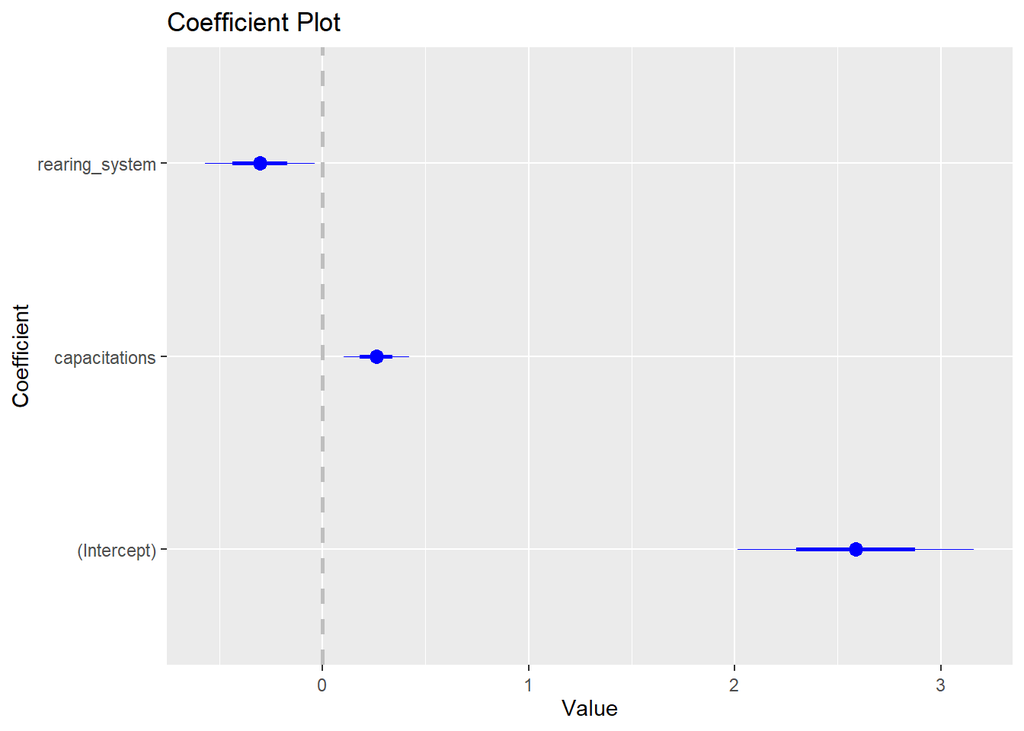

En este grafico podemos ver que el metodo de crianza disminuye la edad a la primera inseminacion, mientras que las capacitacines la aumentan.

Analizo la importancia relativa de las variables presentes en el modelo

```
## Response variable: afb
## Total response variance: 0.2831541
## Analysis based on 63 observations
##
## 2 Regressors:
## capacitations rearing_system
## Proportion of variance explained by model: 21.22%
## Metrics are normalized to sum to 100% (rela=TRUE).
##
## Relative importance metrics:
##
##                      car
## capacitations  0.6794185
## rearing_system 0.3205815
```

Las capacitaciones explican el 68% de la edad a la primera inseminacion y el sistema de crianza el 32%.

## Arbol de clasificacion

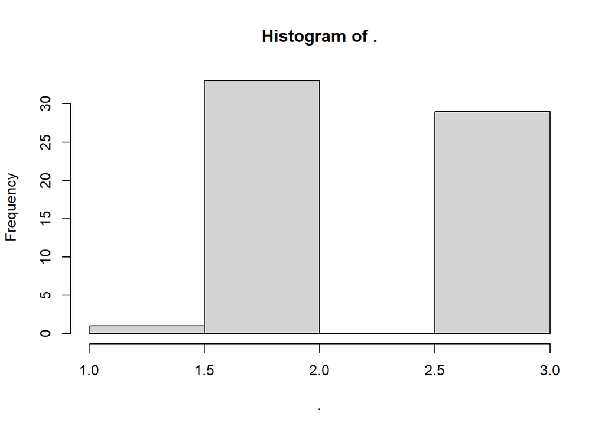

```
## 'data.frame':    63 obs. of  14 variables:
##  $ vacination           : int  1 3 3 2 2 3 2 3 3 3 ...
##  $ prepartum            : int  3 3 2 1 1 2 3 3 1 2 ...
##  $ experience           : int  4 4 2 2 4 1 4 4 3 4 ...
##  $ capacitations        : int  1 2 1 2 1 1 1 1 1 1 ...
##  $ rearing_system       : num  2 2 1 2 1 2.5 2.5 2 1 2 ...
##  $ realiza_calostrado   : int  1 3 1 1 2 1 1 2 2 2 ...
##  $ calostrum_feeding_num: int  2 3 2 2 1 3 1 2 2 1 ...
##  $ clostrum_feeding_vol : int  5 5 3 2 4 5 1 4 3 3 ...
##  $ liquid_feeding_volume: int  2 3 2 2 3 3 3 3 3 3 ...
##  $ hygiene              : int  2 2 3 3 2 1 2 2 1 2 ...
##  $ feed_cows            : int  2 2 2 2 2 2 2 2 2 2 ...
##  $ afb                  : int  3 2 2 2 3 2 2 3 3 2 ...
##  $ ffi                  : int  45 85 35 40 70 60 30 47 30 35 ...
##  $ AFB                  : logi  FALSE FALSE FALSE FALSE FALSE FALSE ...
```

```
##    rowid vacination prepartum experience capacitations rearing_system
## 1      1          1         3          4             1            2.0
## 2      2          3         3          4             2            2.0
## 3      3          3         2          2             1            1.0
## 4      4          2         1          2             2            2.0
## 5      5          2         1          4             1            1.0
## 6      6          3         2          1             1            2.5
## 7      7          2         3          4             1            2.5
## 8      8          3         3          4             1            2.0
## 9      9          3         1          3             1            1.0
## 10    10          3         2          4             1            2.0
## 11    11          3         2          4             1            2.0
## 12    12          2         3          4             1            2.0
## 13    13          3         2          4             1            2.0
## 14    14          3         2          4             2            2.0
```

[output cut: 177 more lines]

```
##   afb >= 15  n prop
## 1     FALSE 63    1
```

```
##    vacination prepartum experience capacitations rearing_system
## 1           1         3          4             1            2.0
## 2           3         3          4             2            2.0
## 3           3         2          2             1            1.0
## 4           2         1          2             2            2.0
## 5           2         1          4             1            1.0
## 6           3         2          1             1            2.5
## 7           2         3          4             1            2.5
## 8           3         3          4             1            2.0
## 9           3         1          3             1            1.0
## 10          3         2          4             1            2.0
## 11          3         2          4             1            2.0
## 12          2         3          4             1            2.0
## 13          3         2          4             1            2.0
## 14          3         2          4             2            2.0
```

[output cut: 177 more lines]

```
##  [1] "vacination"            "prepartum"             "experience"
##  [4] "capacitations"         "rearing_system"        "realiza_calostrado"
##  [7] "calostrum_feeding_num" "clostrum_feeding_vol"  "liquid_feeding_volume"
## [10] "hygiene"               "feed_cows"             "afb"
## [13] "ffi"
```

```
## Call:
## rpart(formula = dat_repr[, targ] ~ ., data = dat_repr[, preds])
##   n= 63
##
##           CP nsplit rel error    xerror      xstd
## 1 0.15995397      0 1.0000000 1.0181246 0.1070939
## 2 0.04153481      2 0.6800921 0.7545880 0.1300648
## 3 0.01458573      3 0.6385572 0.8293111 0.1378143
## 4 0.01000000      4 0.6239715 0.8418849 0.1422422
##
## Variable importance
##    realiza_calostrado         capacitations               hygiene
##                    32                    31                    11
## calostrum_feeding_num            vacination  clostrum_feeding_vol
##                     8                     6                     5
##             prepartum            experience        rearing_system
##                     4                     3                     1
##
## Node number 1: 63 observations,    complexity param=0.159954
##   mean=2.444444, MSE=0.2786596
##   left son=2 (11 obs) right son=3 (52 obs)
##   Primary splits:
##       realiza_calostrado   < 2.5  to the right, improve=0.149951300, (0 missing)
##       capacitations        < 1.5  to the left,  improve=0.113019900, (0 missing)
##       rearing_system       < 1.5  to the right, improve=0.078834700, (0 missing)
##       vacination           < 2.5  to the left,  improve=0.019262520, (0 missing)
##       clostrum_feeding_vol < 2.5  to the left,  improve=0.007814518, (0 missing)
##
## Node number 2: 11 observations
##   mean=2, MSE=0
##
## Node number 3: 52 observations,    complexity param=0.159954
##   mean=2.538462, MSE=0.2869822
##   left son=6 (30 obs) right son=7 (22 obs)
##   Primary splits:
##       capacitations         < 1.5  to the left,  improve=0.19993750, (0 missing)
##       realiza_calostrado    < 1.5  to the left,  improve=0.15205770, (0 missing)
##       vacination            < 2.5  to the left,  improve=0.05856177, (0 missing)
##       rearing_system        < 1.5  to the right, improve=0.04677835, (0 missing)
##       calostrum_feeding_num < 1.5  to the right, improve=0.02061856, (0 missing)
```

[output cut: 35 more lines]

```
##       clostrum_feeding_vol < 2.5  to the left,  agree=0.682, adj=0.3, (0 split)
##       capacitations        < 2.5  to the left,  agree=0.636, adj=0.2, (0 split)
##       realiza_calostrado   < 1.5  to the left,  agree=0.636, adj=0.2, (0 split)
##
## Node number 12: 16 observations
##   mean=2.1875, MSE=0.2773438
##
## Node number 13: 14 observations
##   mean=2.5, MSE=0.25
##
## Node number 14: 10 observations
##   mean=2.7, MSE=0.21
##
## Node number 15: 12 observations
##   mean=2.916667, MSE=0.07638889
```

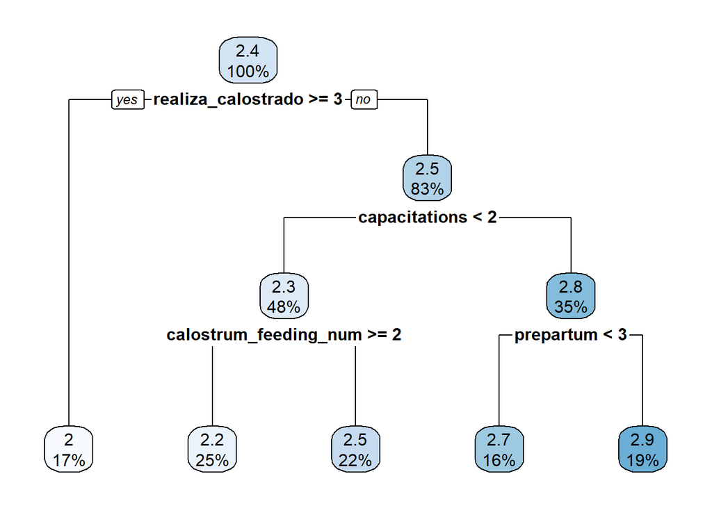

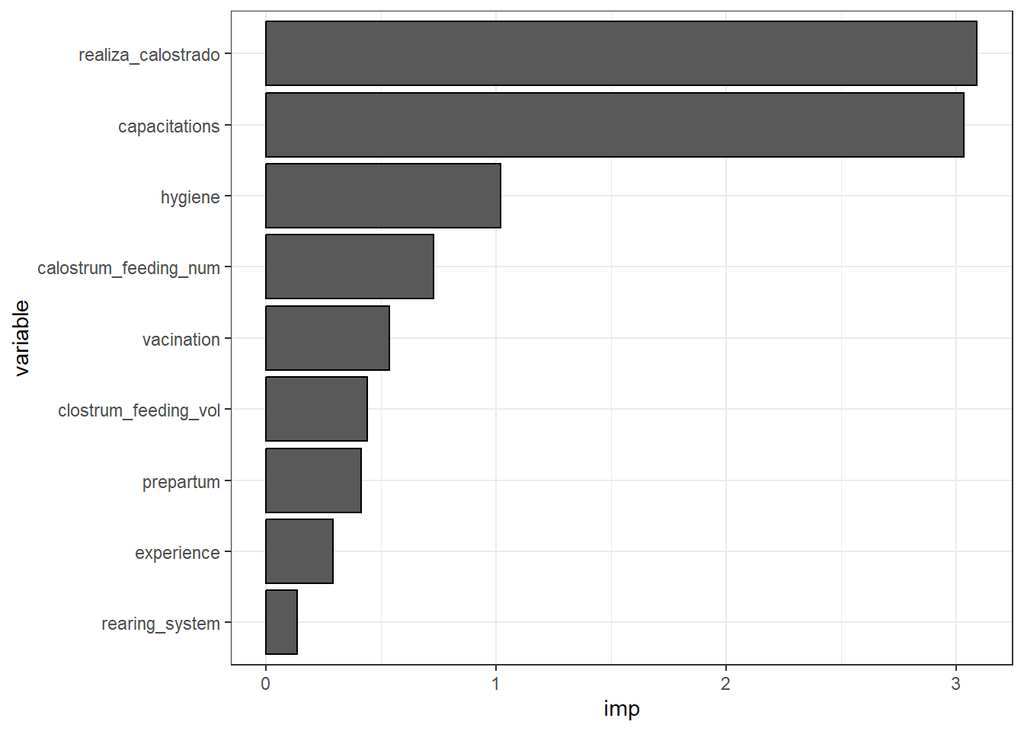

```
## 'data.frame':    63 obs. of  14 variables:
##  $ vacination           : int  1 3 3 2 2 3 2 3 3 3 ...
##  $ prepartum            : int  3 3 2 1 1 2 3 3 1 2 ...
##  $ experience           : int  4 4 2 2 4 1 4 4 3 4 ...
##  $ capacitations        : int  1 2 1 2 1 1 1 1 1 1 ...
##  $ rearing_system       : num  2 2 1 2 1 2.5 2.5 2 1 2 ...
##  $ realiza_calostrado   : int  1 3 1 1 2 1 1 2 2 2 ...
##  $ calostrum_feeding_num: int  2 3 2 2 1 3 1 2 2 1 ...
##  $ clostrum_feeding_vol : int  5 5 3 2 4 5 1 4 3 3 ...
##  $ liquid_feeding_volume: int  2 3 2 2 3 3 3 3 3 3 ...
##  $ hygiene              : int  2 2 3 3 2 1 2 2 1 2 ...
##  $ feed_cows            : int  2 2 2 2 2 2 2 2 2 2 ...
##  $ afb                  : int  3 2 2 2 3 2 2 3 3 2 ...
##  $ ffi                  : int  45 85 35 40 70 60 30 47 30 35 ...
##  $ AFB                  : logi  FALSE FALSE FALSE FALSE FALSE FALSE ...
```

## Regresion logistica

```
##
## Call:
## glm(formula = AFB ~ hygiene + calostrum_feeding_num + realiza_calostrado +
##     capacitations + vacination + experience + rearing_system,
##     family = binomial, data = df)
##
## Coefficients:
##                         Estimate Std. Error z value Pr(>|z|)
## (Intercept)           -2.657e+01  3.628e+05       0        1
## hygiene               -2.080e-15  6.475e+04       0        1
## calostrum_feeding_num  3.186e-15  7.264e+04       0        1
## realiza_calostrado     2.950e-15  7.538e+04       0        1
## capacitations         -6.181e-15  6.745e+04       0        1
## vacination             4.895e-14  9.112e+04       0        1
## experience             2.499e-16  4.304e+04       0        1
## rearing_system         3.169e-15  1.002e+05       0        1
##
## (Dispersion parameter for binomial family taken to be 1)
##
##     Null deviance: 0.000e+00  on 62  degrees of freedom
## Residual deviance: 3.655e-10  on 55  degrees of freedom
## AIC: 16
##
## Number of Fisher Scoring iterations: 25
```

|  | AFB |  |  |
| --- | --- | --- | --- |
| Predictors | Odds Ratios | CI | p |
| (Intercept) | 0.00 | 0.00 – Inf | 1.000 |
| hygiene | 1.00 | 0.00 – Inf | 1.000 |
| calostrum feeding num | 1.00 | 0.00 – Inf | 1.000 |
| realiza calostrado | 1.00 | 0.00 – Inf | 1.000 |
| capacitations | 1.00 | 0.00 – Inf | 1.000 |
| vacination | 1.00 | 0.00 – Inf | 1.000 |
| experience | 1.00 | 0.00 – Inf | 1.000 |
| rearing system | 1.00 | 0.00 – Inf | 1.000 |
| Observations | 63 |  |  |

No hay odds de nada

## Factorizo variables predictoras

Si factorizo las variables predictoras, el modelo queda de la siguiente forma:

```
##    prepartum experience capacitations rearing_system realiza_calostrado
## 1          3          4             1              2                  1
## 2          3          3             1              2                  2
## 3          3          4             2              2                  3
## 4          2          2             1              1                  1
## 5          1          2             2              2                  1
## 6          1          4             1              1                  2
## 7          2          1             1            2.5                  1
## 8          3          4             1            2.5                  1
## 9          3          4             1              2                  2
## 10         1          3             1              1                  2
## 11         2          4             1              2                  2
## 12         2          4             1              2                  2
## 13         3          4             1              2                  2
## 14         2          4             1              2                  2
```

[output cut: 147 more lines]

## Reg. lineal múltiple

```
## Analysis of Variance Table
##
## Response: afb
##                       Df  Sum Sq Mean Sq F value    Pr(>F)
## prepartum              2  0.0688 0.03439  0.1084 0.8974234
## experience             3  0.1220 0.04066  0.1282 0.9430070
## capacitations          2  1.7638 0.88190  2.7803 0.0702998 .
## rearing_system         2  0.9020 0.45102  1.4219 0.2495394
## realiza_calostrado     2  5.2908 2.64538  8.3399 0.0006554 ***
## calostrum_feeding_num  2  0.2324 0.11618  0.3663 0.6949032
## clostrum_feeding_vol   4  0.9933 0.24833  0.7829 0.5409197
## liquid_feeding_volume  2  1.0887 0.54434  1.7161 0.1887661
## hygiene                2  0.5285 0.26426  0.8331 0.4398286
## Residuals             58 18.3973 0.31719
## ---
## Signif. codes:  0 '***' 0.001 '**' 0.01 '*' 0.05 '.' 0.1 ' ' 1
```

```
## Start:  AIC=-73.59
## afb ~ prepartum + experience + capacitations + rearing_system +
##     realiza_calostrado + calostrum_feeding_num + clostrum_feeding_vol +
##     liquid_feeding_volume + hygiene
##
##                         Df Sum of Sq    RSS     AIC
## - prepartum              2    0.0987 18.496 -77.158
## - experience             3    0.6790 19.076 -76.687
## - capacitations          2    0.2671 18.664 -76.433
## - clostrum_feeding_vol   4    1.4751 19.872 -75.416
## - hygiene                2    0.5285 18.926 -75.320
## - calostrum_feeding_num  2    0.6436 19.041 -74.835
## <none>                               18.397 -73.586
## - liquid_feeding_volume  2    1.2352 19.632 -72.387
## - rearing_system         2    1.3087 19.706 -72.088
## - realiza_calostrado     2    4.2479 22.645 -60.967
##
## Step:  AIC=-77.16
## afb ~ experience + capacitations + rearing_system + realiza_calostrado +
##     calostrum_feeding_num + clostrum_feeding_vol + liquid_feeding_volume +
##     hygiene
##
##                         Df Sum of Sq    RSS     AIC
## - experience             3    0.5994 19.095 -80.607
## - capacitations          2    0.2365 18.732 -80.142
## - hygiene                2    0.5181 19.014 -78.948
## - clostrum_feeding_vol   4    1.5821 20.078 -78.592
## - calostrum_feeding_num  2    0.6917 19.188 -78.221
## <none>                               18.496 -77.158
## - liquid_feeding_volume  2    1.1646 19.661 -76.273
## - rearing_system         2    1.4762 19.972 -75.015
## + prepartum              2    0.0987 18.397 -73.586
## - realiza_calostrado     2    4.1671 22.663 -64.903
##
## Step:  AIC=-80.61
## afb ~ capacitations + rearing_system + realiza_calostrado + calostrum_feeding_num +
##     clostrum_feeding_vol + liquid_feeding_volume + hygiene
##
##                         Df Sum of Sq    RSS     AIC
## - capacitations          2    0.2382 19.334 -83.615
```

[output cut: 87 more lines]

```
##
## Step:  AIC=-94.01
## afb ~ realiza_calostrado
##
##                         Df Sum of Sq    RSS     AIC
## <none>                               22.916 -94.014
## + liquid_feeding_volume  2    0.7990 22.117 -92.853
## + rearing_system         2    0.6564 22.260 -92.339
## + capacitations          2    0.5253 22.391 -91.869
## + calostrum_feeding_num  2    0.3082 22.608 -91.097
## + prepartum              2    0.2758 22.641 -90.982
## + hygiene                2    0.1187 22.798 -90.429
## + experience             3    0.4070 22.509 -89.447
## + clostrum_feeding_vol   4    0.4276 22.489 -87.521
## - realiza_calostrado     2    6.4710 29.387 -78.117
```

```
## Analysis of Variance Table
##
## Response: afb
##                    Df Sum Sq Mean Sq F value    Pr(>F)
## realiza_calostrado  2  6.471  3.2355  10.871 6.942e-05 ***
## Residuals          77 22.916  0.2976
## ---
## Signif. codes:  0 '***' 0.001 '**' 0.01 '*' 0.05 '.' 0.1 ' ' 1
```

Cuando factorizo el metodo de calostrado impacta en la edad a la primera inseminacion

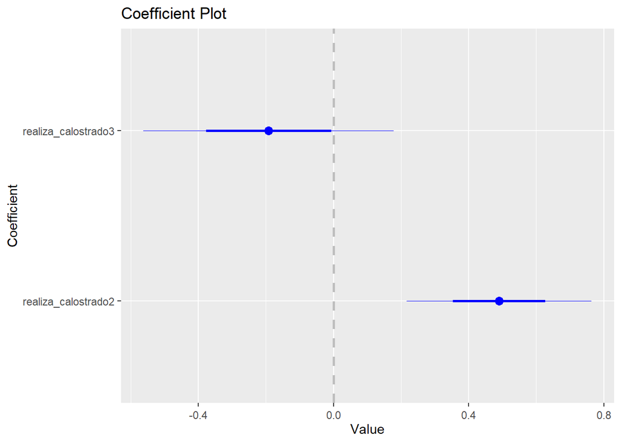

```
## Start:  AIC=155.44
## afb ~ prepartum + experience + capacitations + rearing_system +
##     realiza_calostrado + calostrum_feeding_num + clostrum_feeding_vol +
##     liquid_feeding_volume + hygiene
##
##                         Df Deviance    AIC
## - prepartum              2   18.496 151.87
## - experience             3   19.076 152.34
## - capacitations          2   18.664 152.60
## - clostrum_feeding_vol   4   19.872 153.61
## - hygiene                2   18.926 153.71
## - calostrum_feeding_num  2   19.041 154.19
## <none>                       18.397 155.44
## - liquid_feeding_volume  2   19.632 156.64
## - rearing_system         2   19.706 156.94
## - realiza_calostrado     2   22.645 168.06
##
## Step:  AIC=151.87
## afb ~ experience + capacitations + rearing_system + realiza_calostrado +
##     calostrum_feeding_num + clostrum_feeding_vol + liquid_feeding_volume +
##     hygiene
##
##                         Df Deviance    AIC
## - experience             3   19.095 148.42
## - capacitations          2   18.732 148.89
## - hygiene                2   19.014 150.08
## - clostrum_feeding_vol   4   20.078 150.44
## - calostrum_feeding_num  2   19.188 150.81
## <none>                       18.496 151.87
## - liquid_feeding_volume  2   19.661 152.76
## - rearing_system         2   19.972 154.01
## + prepartum              2   18.397 155.44
## - realiza_calostrado     2   22.663 164.13
##
## Step:  AIC=148.42
## afb ~ capacitations + rearing_system + realiza_calostrado + calostrum_feeding_num +
##     clostrum_feeding_vol + liquid_feeding_volume + hygiene
##
##                         Df Deviance    AIC
## - capacitations          2   19.334 145.41
```

[output cut: 87 more lines]

```
##
## Step:  AIC=135.02
## afb ~ realiza_calostrado
##
##                         Df Deviance    AIC
## <none>                       22.916 135.02
## + liquid_feeding_volume  2   22.117 136.18
## + rearing_system         2   22.260 136.69
## + capacitations          2   22.391 137.16
## + calostrum_feeding_num  2   22.608 137.93
## + prepartum              2   22.641 138.05
## + hygiene                2   22.798 138.60
## + experience             3   22.509 139.58
## + clostrum_feeding_vol   4   22.489 141.51
## - realiza_calostrado     2   29.387 150.91
```

```
## Analysis of Deviance Table (Type II tests)
##
## Response: afb
##                    LR Chisq Df Pr(>Chisq)
## realiza_calostrado   21.743  2  1.899e-05 ***
## ---
## Signif. codes:  0 '***' 0.001 '**' 0.01 '*' 0.05 '.' 0.1 ' ' 1
```

```
##
## Call:
## glm(formula = afb ~ realiza_calostrado, data = repr_new)
##
## Coefficients:
##                     Estimate Std. Error t value Pr(>|t|)
## (Intercept)           2.1923     0.1070  20.491  < 2e-16 ***
## realiza_calostrado2   0.4906     0.1368   3.587 0.000585 ***
## realiza_calostrado3  -0.1923     0.1853  -1.038 0.302633
## ---
## Signif. codes:  0 '***' 0.001 '**' 0.01 '*' 0.05 '.' 0.1 ' ' 1
##
## (Dispersion parameter for gaussian family taken to be 0.297617)
##
##     Null deviance: 29.387  on 79  degrees of freedom
## Residual deviance: 22.917  on 77  degrees of freedom
## AIC: 135.02
##
## Number of Fisher Scoring iterations: 2
```

|  | afb |  |  |
| --- | --- | --- | --- |
| Predictors | Estimates | CI | p |
| (Intercept) | 2.19 | 1.98 – 2.40 | **<0.001** |
| realiza calostrado [2] | 0.49 | 0.22 – 0.76 | **<0.001** |
| realiza calostrado [3] | -0.19 | -0.56 – 0.17 | 0.299 |
| Observations | 80 |  |  |
| R<sup>2</sup> | 0.220 |  |  |

```
## $odds_data
## # A tibble: 2 × 4
##      OR lower upper vars
##   <dbl> <dbl> <dbl> <chr>
## 1 1.63  1.25   2.14 realiza_calostrado2
## 2 0.825 0.574  1.19 realiza_calostrado3
##
## $odds_plot
```

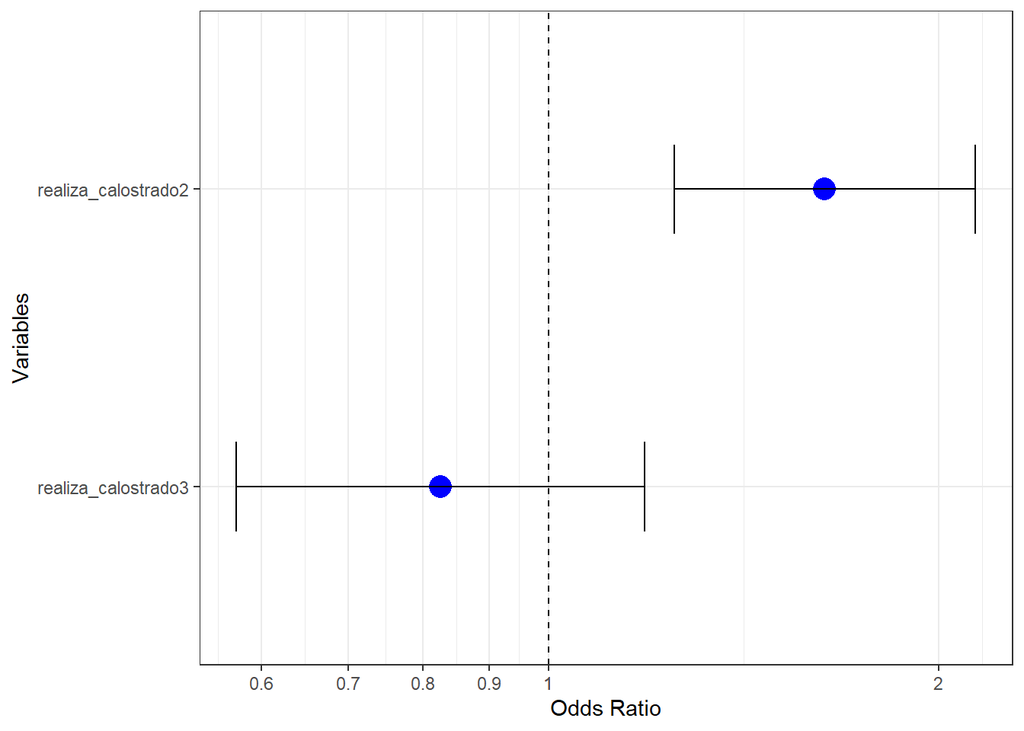

## Árbol de clasificación

```
## n= 80
##
## node), split, n, deviance, yval
##       * denotes terminal node
##
##  1) root 80 29.387500 2.412500
##    2) realiza_calostrado=1,3 39 10.358970 2.128205
##      4) hygiene=3 11  2.909091 1.909091 *
##      5) hygiene=1,2 28  6.714286 2.214286
##       10) realiza_calostrado=3 9  0.000000 2.000000 *
##       11) realiza_calostrado=1 19  6.105263 2.315789 *
##    3) realiza_calostrado=2 41 12.878050 2.682927
##      6) rearing_system=2 25  8.240000 2.520000
##       12) capacitations=1 13  2.769231 2.307692 *
##       13) capacitations=2,3 12  4.250000 2.750000 *
##      7) rearing_system=1,2.5 16  2.937500 2.937500 *
```

```
## Call:
## rpart(formula = afb ~ ., data = repr_new)
##   n= 80
##
##           CP nsplit rel error    xerror      xstd
## 1 0.20928888      0 1.0000000 1.0220500 0.1416986
## 2 0.05786640      1 0.7907111 0.8314380 0.1479443
## 3 0.04154042      2 0.7328447 0.9167555 0.1825861
## 4 0.02503097      3 0.6913043 0.9374185 0.1925433
## 5 0.02072386      4 0.6662733 0.9311779 0.1905213
## 6 0.01000000      5 0.6455495 0.9329939 0.1896704
##
## Variable importance
##    realiza_calostrado         capacitations               hygiene
##                    34                    15                    13
##  clostrum_feeding_vol        rearing_system liquid_feeding_volume
##                    12                     9                     7
## calostrum_feeding_num             prepartum            experience
##                     6                     2                     2
##
## Node number 1: 80 observations,    complexity param=0.2092889
##   mean=2.4125, MSE=0.3673437
##   left son=2 (39 obs) right son=3 (41 obs)
##   Primary splits:
##       realiza_calostrado    splits as  LRL,   improve=0.20928890, (0 missing)
##       rearing_system        splits as  RLR,   improve=0.04497870, (0 missing)
##       calostrum_feeding_num splits as  RRL,   improve=0.04441712, (0 missing)
##       capacitations         splits as  LRR,   improve=0.04308011, (0 missing)
##       clostrum_feeding_vol  splits as  LLRRR, improve=0.01557526, (0 missing)
##   Surrogate splits:
##       hygiene               splits as  LLR,   agree=0.662, adj=0.308, (0 split)
##       clostrum_feeding_vol  splits as  LLRRR, agree=0.650, adj=0.282, (0 split)
##       capacitations         splits as  LRR,   agree=0.613, adj=0.205, (0 split)
##       calostrum_feeding_num splits as  LRL,   agree=0.613, adj=0.205, (0 split)
##       liquid_feeding_volume splits as  RLR,   agree=0.588, adj=0.154, (0 split)
##
## Node number 2: 39 observations,    complexity param=0.02503097
##   mean=2.128205, MSE=0.2656147
##   left son=4 (11 obs) right son=5 (28 obs)
##   Primary splits:
```

[output cut: 51 more lines]

```
##
## Node number 7: 16 observations
##   mean=2.9375, MSE=0.1835938
##
## Node number 10: 9 observations
##   mean=2, MSE=0
##
## Node number 11: 19 observations
##   mean=2.315789, MSE=0.3213296
##
## Node number 12: 13 observations
##   mean=2.307692, MSE=0.2130178
##
## Node number 13: 12 observations
##   mean=2.75, MSE=0.3541667
```

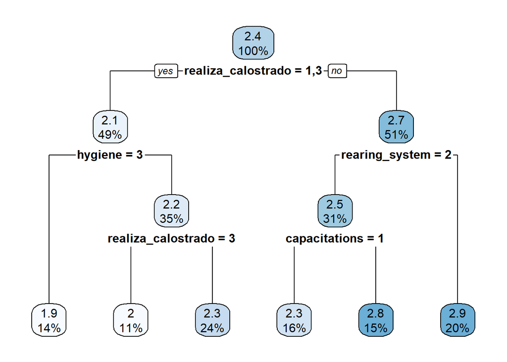

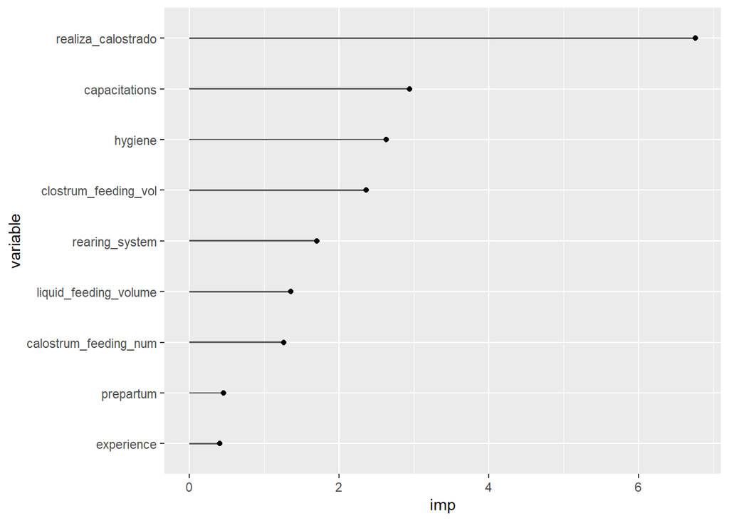

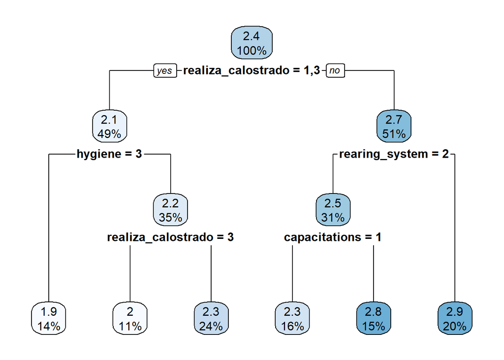

```
## afb is 1.9 when
##     realiza_calostrado is 1 or 3
##     hygiene is 3
##
## afb is 2.0 when
##     realiza_calostrado is 3
##     hygiene is 1 or 2
##
## afb is 2.3 when
##     realiza_calostrado is 2
##     rearing_system is 2
##     capacitations is 1
##
## afb is 2.3 when
##     realiza_calostrado is 1
##     hygiene is 1 or 2
##
## afb is 2.8 when
##     realiza_calostrado is 2
##     rearing_system is 2
##     capacitations is 2 or 3
##
## afb is 2.9 when
##     realiza_calostrado is 2
##     rearing_system is 1 or 2.5
```

```
##    realiza_calostrado         capacitations               hygiene
##                  34.0                  14.8                  13.2
##  clostrum_feeding_vol        rearing_system liquid_feeding_volume
##                  11.9                   8.6                   6.8
## calostrum_feeding_num             prepartum            experience
##                   6.4                   2.3                   2.0
```

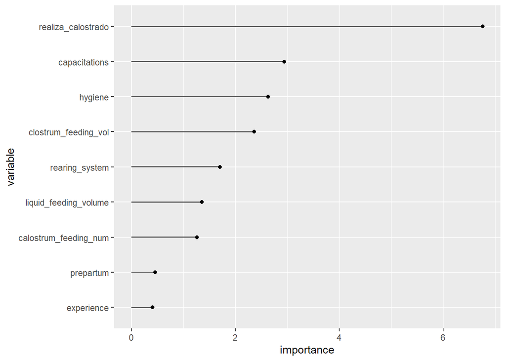

### Fertility at first insemination

```
## Anova Table (Type II tests)
##
## Response: ffi
##                     Sum Sq Df F value  Pr(>F)
## prepartum           1137.2  1  4.5251 0.03759 *
## realiza_calostrado   287.8  1  1.1453 0.28889
## hygiene              135.5  1  0.5391 0.46572
## Residuals          14827.1 59
## ---
## Signif. codes:  0 '***' 0.001 '**' 0.01 '*' 0.05 '.' 0.1 ' ' 1
```

```
##
## Call:
## lm(formula = ffi ~ ., data = na.omit(dat_repr))
##
## Residuals:
##     Min      1Q  Median      3Q     Max
## -30.502 -10.545  -1.616   7.372  42.390
##
## Coefficients:
##                       Estimate Std. Error t value Pr(>|t|)
## (Intercept)            66.4893    26.5696   2.502   0.0156 *
## vacination             -2.3633     4.2464  -0.557   0.5803
## prepartum               7.8523     3.9058   2.010   0.0498 *
## experience             -0.8758     2.1883  -0.400   0.6907
## capacitations           2.6716     3.7645   0.710   0.4812
## rearing_system         -5.5858     5.1140  -1.092   0.2800
## realiza_calostrado      3.0583     3.8514   0.794   0.4309
## calostrum_feeding_num   0.3858     4.4633   0.086   0.9315
## clostrum_feeding_vol    0.9240     2.8511   0.324   0.7472
## liquid_feeding_volume  -4.3047     5.1400  -0.837   0.4063
## hygiene                -3.2508     3.2209  -1.009   0.3177
## feed_cows               2.4338     6.1689   0.395   0.6949
## afb                    -6.1245     4.6689  -1.312   0.1956
## ---
## Signif. codes:  0 '***' 0.001 '**' 0.01 '*' 0.05 '.' 0.1 ' ' 1
##
## Residual standard error: 16.51 on 50 degrees of freedom
## Multiple R-squared:  0.156,  Adjusted R-squared:  -0.04659
## F-statistic:  0.77 on 12 and 50 DF,  p-value: 0.6774
```

```
## Start:  AIC=364.75
## ffi ~ vacination + prepartum + experience + capacitations + rearing_system +
##     realiza_calostrado + calostrum_feeding_num + clostrum_feeding_vol +
##     liquid_feeding_volume + hygiene + feed_cows + afb
##
##                         Df Sum of Sq   RSS    AIC
## - calostrum_feeding_num  1      2.04 13633 362.76
## - clostrum_feeding_vol   1     28.64 13660 362.88
## - feed_cows              1     42.43 13674 362.95
## - experience             1     43.67 13675 362.95
## - vacination             1     84.45 13716 363.14
## - capacitations          1    137.31 13769 363.38
## - realiza_calostrado     1    171.90 13803 363.54
## - liquid_feeding_volume  1    191.22 13822 363.63
## - hygiene                1    277.70 13909 364.02
## - rearing_system         1    325.24 13956 364.24
## <none>                               13631 364.75
## - afb                    1    469.11 14100 364.88
## - prepartum              1   1101.91 14733 367.65
##
## Step:  AIC=362.76
## ffi ~ vacination + prepartum + experience + capacitations + rearing_system +
##     realiza_calostrado + clostrum_feeding_vol + liquid_feeding_volume +
##     hygiene + feed_cows + afb
##
##                         Df Sum of Sq   RSS    AIC
## - feed_cows              1     40.42 13674 360.95
## - experience             1     45.31 13679 360.97
## - clostrum_feeding_vol   1     58.74 13692 361.03
## - vacination             1     85.93 13719 361.16
## - capacitations          1    135.66 13769 361.38
## - realiza_calostrado     1    171.95 13805 361.55
## - liquid_feeding_volume  1    224.43 13858 361.79
## - hygiene                1    300.13 13933 362.13
## - rearing_system         1    334.27 13968 362.29
## <none>                               13633 362.76
## - afb                    1    498.16 14132 363.02
## + calostrum_feeding_num  1      2.04 13631 364.75
## - prepartum              1   1186.82 14820 366.02
##
```

[output cut: 172 more lines]

```
##
##                         Df Sum of Sq   RSS    AIC
## <none>                               15179 349.53
## + liquid_feeding_volume  1    309.32 14870 350.23
## + realiza_calostrado     1    216.47 14963 350.62
## + afb                    1    200.40 14979 350.69
## + feed_cows              1    194.94 14984 350.71
## + experience             1     80.26 15099 351.19
## + rearing_system         1     77.66 15101 351.20
## + capacitations          1     71.37 15108 351.23
## + hygiene                1     64.12 15115 351.26
## + calostrum_feeding_num  1     34.20 15145 351.38
## - prepartum              1    971.28 16150 351.43
## + clostrum_feeding_vol   1      2.99 15176 351.51
## + vacination             1      0.10 15179 351.53
```

```
##
## Call:
## lm(formula = ffi ~ prepartum, data = na.omit(dat_repr))
##
## Residuals:
##     Min      1Q  Median      3Q     Max
## -26.520 -12.769  -0.269   9.731  43.480
##
## Coefficients:
##             Estimate Std. Error t value Pr(>|t|)
## (Intercept)   37.768      7.791   4.848 8.97e-06 ***
## prepartum      6.251      3.164   1.976   0.0527 .
## ---
## Signif. codes:  0 '***' 0.001 '**' 0.01 '*' 0.05 '.' 0.1 ' ' 1
##
## Residual standard error: 15.77 on 61 degrees of freedom
## Multiple R-squared:  0.06014,    Adjusted R-squared:  0.04473
## F-statistic: 3.903 on 1 and 61 DF,  p-value: 0.05272
```

Como se puede ver en ambos modelos, la fertilidad a la primera inseminacion se ve afectada (tendencia) por las caracteristicas del preparto

## Factorizo variables predictoras

Si factorizo las variables predictoras, el modelo queda de la siguiente forma:

```
##    prepartum experience capacitations rearing_system realiza_calostrado
## 1          3          4             1              2                  1
## 2          3          4             2              2                  3
## 3          2          2             1              1                  1
## 4          1          2             2              2                  1
## 5          1          4             1              1                  2
## 6          2          1             1            2.5                  1
## 7          3          4             1            2.5                  1
## 8          3          4             1              2                  2
## 9          1          3             1              1                  2
## 10         2          4             1              2                  2
## 11         2          4             1              2                  2
## 12         3          4             1              2                  2
## 13         2          4             1              2                  2
## 14         2          4             2              2                  3
```

[output cut: 115 more lines]

## Reg. lineal múltiple

```
## Analysis of Variance Table
##
## Response: ffi
##                       Df  Sum Sq Mean Sq F value Pr(>F)
## prepartum              2  1178.0  589.02  2.0741 0.1381
## experience             3   554.5  184.84  0.6509 0.5867
## capacitations          2   503.4  251.68  0.8863 0.4196
## rearing_system         2   582.1  291.03  1.0248 0.3675
## realiza_calostrado     2   587.4  293.68  1.0341 0.3642
## calostrum_feeding_num  2   428.7  214.34  0.7547 0.4763
## clostrum_feeding_vol   4   269.0   67.24  0.2368 0.9160
## liquid_feeding_volume  1   102.9  102.93  0.3624 0.5503
## hygiene                2    39.7   19.83  0.0698 0.9327
## Residuals             43 12211.4  283.99
```

```
## Start:  AIC=378.08
## ffi ~ prepartum + experience + capacitations + rearing_system +
##     realiza_calostrado + calostrum_feeding_num + clostrum_feeding_vol +
##     liquid_feeding_volume + hygiene
##
##                         Df Sum of Sq   RSS    AIC
## - clostrum_feeding_vol   4    260.89 12472 371.43
## - experience             3    352.19 12564 373.90
## - hygiene                2     39.65 12251 374.29
## - capacitations          2    259.34 12471 375.42
## - realiza_calostrado     2    306.53 12518 375.67
## - calostrum_feeding_num  2    412.48 12624 376.21
## - liquid_feeding_volume  1     98.28 12310 376.59
## - rearing_system         2    675.14 12887 377.52
## <none>                               12211 378.08
## - prepartum              2   1254.39 13466 380.34
##
## Step:  AIC=371.43
## ffi ~ prepartum + experience + capacitations + rearing_system +
##     realiza_calostrado + calostrum_feeding_num + liquid_feeding_volume +
##     hygiene
##
##                         Df Sum of Sq   RSS    AIC
## - experience             3    372.79 12845 367.32
## - hygiene                2     23.10 12495 367.55
## - realiza_calostrado     2    303.16 12776 368.97
## - capacitations          2    381.31 12854 369.36
## - calostrum_feeding_num  2    443.44 12916 369.67
## - liquid_feeding_volume  1    131.85 12604 370.11
## - rearing_system         2    570.06 13042 370.29
## <none>                               12472 371.43
## - prepartum              2   1371.99 13844 374.11
## + clostrum_feeding_vol   4    260.89 12211 378.08
##
## Step:  AIC=367.32
## ffi ~ prepartum + capacitations + rearing_system + realiza_calostrado +
##     calostrum_feeding_num + liquid_feeding_volume + hygiene
##
##                         Df Sum of Sq   RSS    AIC
## - hygiene                2     32.34 12877 363.48
```

[output cut: 86 more lines]

```
##
## Step:  AIC=356.42
## ffi ~ prepartum
##
##                         Df Sum of Sq   RSS    AIC
## <none>                               15279 356.42
## + realiza_calostrado     2    891.37 14388 356.58
## + liquid_feeding_volume  1    329.59 14949 357.03
## - prepartum              2   1178.04 16457 357.18
## + calostrum_feeding_num  2    581.55 14697 357.94
## + rearing_system         2    449.88 14829 358.51
## + capacitations          2    386.67 14892 358.78
## + hygiene                2    143.22 15136 359.82
## + experience             3    554.53 14724 360.06
## + clostrum_feeding_vol   4    483.38 14796 362.36
```

```
## Analysis of Variance Table
##
## Response: ffi
##           Df Sum Sq Mean Sq F value Pr(>F)
## prepartum  2   1178  589.02  2.3516 0.1038
## Residuals 61  15279  250.47
```

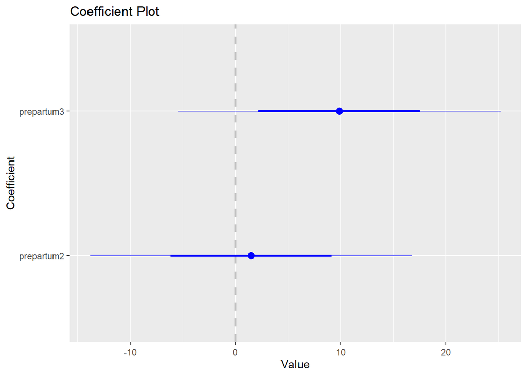

## Reg log - ffi

```
## Start:  AIC=561.7
## ffi ~ prepartum + experience + capacitations + rearing_system +
##     realiza_calostrado + calostrum_feeding_num + clostrum_feeding_vol +
##     liquid_feeding_volume + hygiene
##
##                         Df Deviance    AIC
## - clostrum_feeding_vol   4    12472 555.06
## - experience             3    12564 557.52
## - hygiene                2    12251 557.91
## - capacitations          2    12471 559.05
## - realiza_calostrado     2    12518 559.29
## - calostrum_feeding_num  2    12624 559.83
## - liquid_feeding_volume  1    12310 560.22
## - rearing_system         2    12887 561.15
## <none>                        12211 561.70
## - prepartum              2    13466 563.96
##
## Step:  AIC=555.06
## ffi ~ prepartum + experience + capacitations + rearing_system +
##     realiza_calostrado + calostrum_feeding_num + liquid_feeding_volume +
##     hygiene
##
##                         Df Deviance    AIC
## - experience             3    12845 550.94
## - hygiene                2    12495 551.18
## - realiza_calostrado     2    12776 552.59
## - capacitations          2    12854 552.98
## - calostrum_feeding_num  2    12916 553.29
## - liquid_feeding_volume  1    12604 553.73
## - rearing_system         2    13042 553.92
## <none>                        12472 555.06
## - prepartum              2    13844 557.74
## + clostrum_feeding_vol   4    12211 561.70
##
## Step:  AIC=550.94
## ffi ~ prepartum + capacitations + rearing_system + realiza_calostrado +
##     calostrum_feeding_num + liquid_feeding_volume + hygiene
##
##                         Df Deviance    AIC
## - hygiene                2    12877 547.10
```

[output cut: 86 more lines]

```
##
## Step:  AIC=540.05
## ffi ~ prepartum
##
##                         Df Deviance    AIC
## <none>                        15279 540.05
## + realiza_calostrado     2    14388 540.20
## + liquid_feeding_volume  1    14949 540.65
## - prepartum              2    16457 540.80
## + calostrum_feeding_num  2    14697 541.56
## + rearing_system         2    14829 542.13
## + capacitations          2    14892 542.41
## + hygiene                2    15136 543.44
## + experience             3    14724 543.68
## + clostrum_feeding_vol   4    14796 545.99
```

```
## Analysis of Deviance Table (Type II tests)
##
## Response: ffi
##           LR Chisq Df Pr(>Chisq)
## prepartum   4.7032  2    0.09522 .
## ---
## Signif. codes:  0 '***' 0.001 '**' 0.01 '*' 0.05 '.' 0.1 ' ' 1
```

```
##
## Call:
## glm(formula = ffi ~ prepartum, data = repr_new2)
##
## Coefficients:
##             Estimate Std. Error t value Pr(>|t|)
## (Intercept)   47.200      7.078   6.669 8.57e-09 ***
## prepartum2     1.500      7.645   0.196    0.845
## prepartum3     9.869      7.664   1.288    0.203
## ---
## Signif. codes:  0 '***' 0.001 '**' 0.01 '*' 0.05 '.' 0.1 ' ' 1
##
## (Dispersion parameter for gaussian family taken to be 250.4748)
##
##     Null deviance: 16457  on 63  degrees of freedom
## Residual deviance: 15279  on 61  degrees of freedom
## AIC: 540.05
##
## Number of Fisher Scoring iterations: 2
```